# Reproducible data analysis using RMarkdown

## About me: Jens Roeser

- Senior Lecturer in Psycholinguistics @ Psychology Department
- Language production / comprehension / acquisition often with a focus on writing (e.g. Roeser, Torrance, and Baguley 2019; Garcia, Roeser, and Kidd 2023)
- Bayesian modelling of production time course data (Roeser, De Maeyer, et al. 2024; Roeser, Conijn, et al. 2024); keystroke logging; eyetracking
- Teaching: advanced statistical modelling, data wrangling, data visualisation, R package (`psyntur`, Andrews and Roeser 2021)

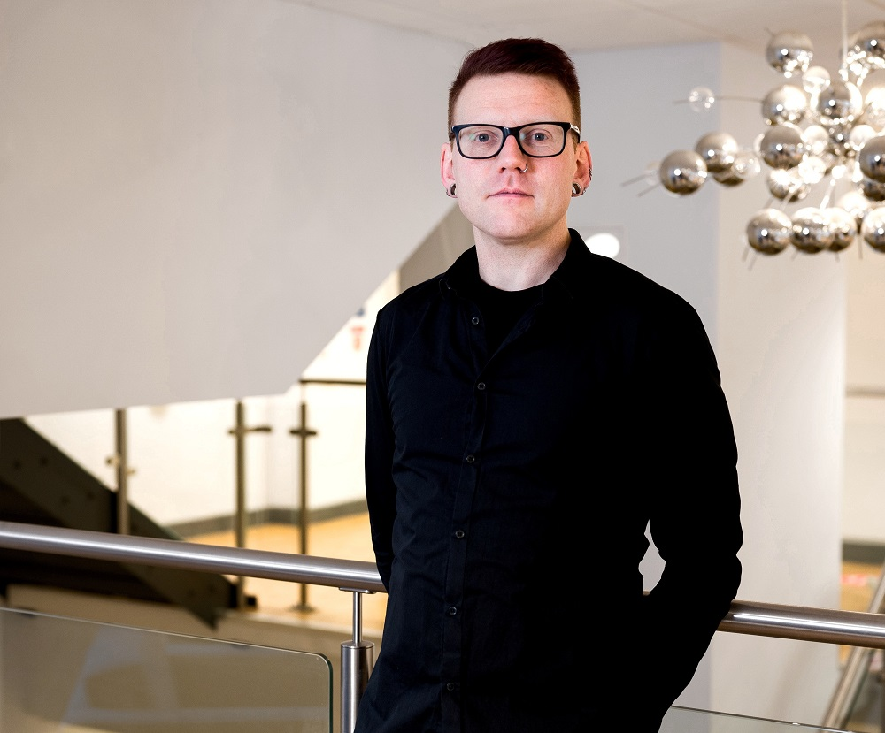

## Reproducible data analysis using RMarkdown

## How can you trust someone’s results?

- Results are communicated through reports such as peer reviewed scientific articles.
- Analysis and results should be reproducible.
- Data and code should be made publically available.
- Often difficult to relate code to figures, tables, numbers in text.
- Copy-pasting numbers from software into the text can be error prone.

## Why do we need reproducible analyses?

- Open Science Collaboration led by Brian Nosek (Open Science Collaboration 2015).
- Aimed to replicate important findings in psychological research.
- Main finding: 36% where replicated; only 23% for Social Psychology
- Reasons: small samples, pressure to publish sensational results.
- Make Psychology Science Again: pre-registration, replications, transparency, large samples (power analysis), abandoning significance testing.

[figure not shown]

## Markdown: a truely reproducible report

- Data, code, report need be one unit.
- Based on the concept of *literate programming* (Knuth 1984): text and code are linked in one single file to generate manual or computer program.
- This principle can be used to creating reproducible reports, sometimes known as *dynamic documents* (Xie 2017).
- RMarkdown is the best way of doing this using R.

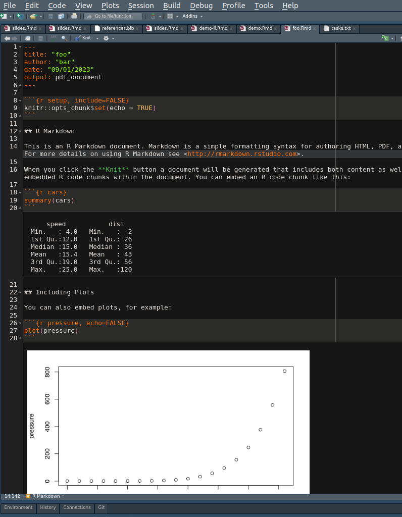

## Why RMarkdown?

[figure not shown]

- Documentation of all analysis steps
- Easy integration between R and text
- Quickly updating and reproducing analysis
- No copy-pasting between programmes
- Producing texts, website, supplementary materials, APA-style manuscripts, slides
- Easy cross-referencing (citations)
- Automatic reference lists
- Easy type-setting of equations

## Key concepts and tools

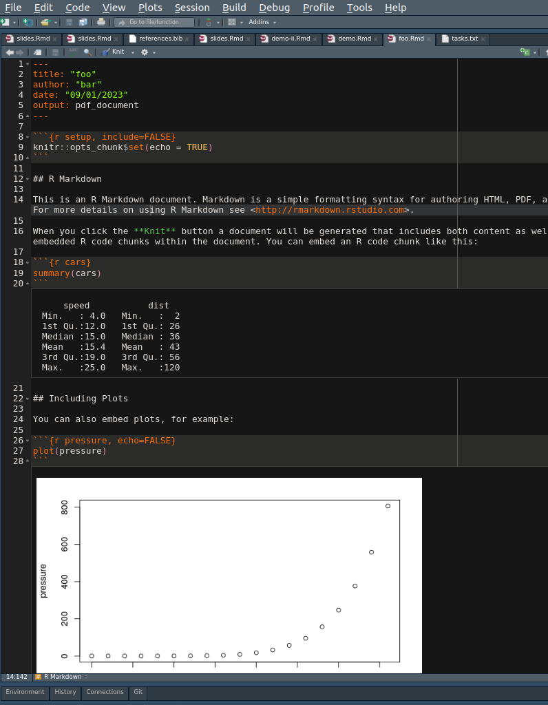

> What is RMarkdown?
- Text file format, a script like an R script.
- Open, edit, run in RStudio like scripts.
- RMarkdown are a mixture of *markdown* code and normal R code (and your data).
- R code in RMarkdown documents occurs in R *chunks*, i.e. blocks of code, or *inline* R code inside of markdown code
- Markdown: minimal syntax that instructs how text should be formatted.
- Rendering into `.pdf`, `.html`, `.docx`, `.doc`

## Key concepts and tools

[figure not shown]

- Document preparation system for creating high quality technical and scientific documents especially when involving mathematical formulas and technical diagrams.
- Great for cross referencing (citations, figure labels) and automatic generation of content tables, reference lists.
- Widely used in statistics, computer science, physics
- \(\LaTeX\) documents are written in a `.tex` source code file and rendered to pdf

## Outline

- Setup
- Examples
- YAML preamble and chunk options
- Headers
- Figures and tables
- Cross-referencing
- Referencing
- In-line R output
- Mathematical typesetting

## Download repository

- Go to github.com/jensroes/bristol-ws-2025
- Click on: `Code` > `Download ZIP` > unzip directory on your machine.
- Open project by double clicking on `bristol-ws-2025.Rproj`
- Use slides for code

## Installation

- RStudio comes with necessary R package `rmarkdown`
- To create pdf outputs, we require the package `tinytex`

```r
# Is tidyverse installed?
'tidyverse' %in% rownames(installed.packages())
# Should return TRUE but if not run
install.packages('tidyverse')
```

```r
install.packages('tinytex')
tinytex::install_tinytex()
# then restart RStudio
```

```r
# Then, try
tinytex:::is_tinytex() # should return TRUE
```

## Installation

- Test that `rmarkdown` will render pdf documents:

```r
writeLines('Hello $x^2$', 'test.Rmd')
rmarkdown::render('test.Rmd', output_format = 'pdf_document')
```

- `writeLines` creates an `.Rmd` file named `test.Rmd`.
- `rmarkdown::render` renders `.Rmd` as pdf named `test.pdf`.

## Minimal RMarkdown example

- Open `rmarkdown/examples/example.Rmd`
- You’ll see an R *chunk* and two pieces of inline R code.
- Remainder is plain Markdown.
- `Knit > Knit to PDF` to compile `.Rmd` to `.pdf`. Wow!!!
- Notice how the code was interpreted in pdf.
- Important: R code is executed from top down.
- Other demos and examples are provided.

## Elaborate APA7 RMarkdown example

- Open `rmarkdown/examples/apa7_template.Rmd`
- To run this, you might need to install a few packages so instead
- Check out the file `rmarkdown/examples/apa7_template.pdf` that was rendered with this .Rmd file

## Example for online supp materials

- Open `rmarkdown/examples/robobook.Rmd`
- To run this, you might need to install a few packages so instead
- Check out the file `rmarkdown/examples/robobook.html` that was rendered with this .Rmd file

## From the RStudio menu …

- Click on `File` > `New File` > `R Markdown`
- Document (PDF, WORD, HTML)
- `output: pdf_document`: use pdfs for writing manuscripts
- Name your RMarkdown: `my-practice-markdown.Rmd`
- Save in same directory as `.Rproj` file.
- YAML header between `'---'`s
- YAML = YAML Ain’t a Markup Language (o Yet Another Markup Language)

## Load data

- Create a new *R chunk*: try `CTRL+ALT+I` or `CMD+ALT+I` (i.e. the letter “i”)
- Create a chunk called `packages` and load libraries needed:

```r
library(tidyverse)
```

- Create a new chunk called `loaddata` and load Martin et al. (2010) data:

```r
data <- read_csv("data/martin-etal-2010-exp3a.csv")
```

## The setup chunk: global options

- Note ````{r setup, echo=FALSE}`
- `setup` is a label of this chunk (optional; useful for cross-referencing of figures and tables).
- Chunk configuration option `echo = FALSE`: don’t display chunk in output; `echo = TRUE`: display chunk.

```r
knitr::opts_chunk$set(message = FALSE, # don't return messages
                      warning = FALSE, # don't return warnings
                      comment = NA, # don't comment output
                      echo = TRUE, # display chunk (is default)
                      eval = TRUE, # evaluate chunk (is default)
                      out.width = '45%',  # figure width
                      fig.align='center') # figure alignment
```

## Section headers

```
# This is a section header

## This is a subsection header

# This is another section header

## This is another subsection header

### This is a subsubsection header
```

## Figures

- Create a new *R chunk* with label `mydensplot`
- Set `echo = F` cause we only need the figure.
- Add a figure caption `fig.cap = "A density plot."` in the chunk configurations.

```r
ggplot(data, aes(x = rt, colour = nptype, fill = nptype)) +
    geom_density(alpha = .25) +
    scale_x_log10() +
    theme_classic()
```

[output not shown]

## Figures

- Change the default size to `out.width = 50%`.
- Cross-reference figure using `\ref{fig:mydensplot}` in the text.

```
"A density plot of reaction time visualised by NP type can be found in Figure \ref{fig:mydensplot}."
```

## Add header options

```
header-includes:
- \usepackage{booktabs}
```

- We just need `booktabs` to improve type setting.

## Formatted tables

- Reporting results in tables formatted to a high standard.
- Calculate descriptive summary stats:

```r
(rt_stats <- summarise(data, across(rt, list(mean = mean, sd = sd)), .by = nptype))
```

```
# A tibble: 2 × 3
  nptype    rt_mean rt_sd
  <chr>       <dbl> <dbl>
1 conjoined   1109.  296.
2 simple      1076.  267.
```

- This format isn’t good enough for papers.

## Formatted APA style tables

```r
library(kableExtra)
kable(rt_stats,
      format = 'latex',
      booktabs = TRUE,
      digits = 2,
      align = 'c', # centre value in each column
      caption = 'Descriptive summary statistics of reaction time by NP type.') %>%
  kable_styling(position = 'center') # centre position of table
```

Also, label your chunk “`rtstats`” and cross-reference the table in the text using `Table \ref{tab:rtstats}`.

## Bibliography and citations

Add to the YAML preamble:

```r
bibliography: refs.bib
biblio-style: apalike
```

Create a file (in RStudio) called `refs.bib` (save in same working directory as your `.Rmd` file)

## Bibliography and citations

- Get the `.bib` entry for Martin et al. (2010) from Google Scholar and paste it into `refs.bib`:
  - Copy the title “Planning in sentence production: Evidence for the phrase as a default planning scope” into Google Scholar
  - Click `cite` and `BibTeX`
  - Copy the `.bib` entry into `refs.bib`
- Note the citation *key* `martin2010planning`
- Cite Martin et al. (2010) using `@martin2010planning` or `[@martin2010planning]`.
- At the end of your document create a section “`# References`”

## Table exercise

```r
# Fit model and get the summary
library(lmerTest)
model <- lmer(rt ~ nptype + (nptype|ppt) + (nptype|item), data = data)
model_summary <- summary(model)$coefficients
```

Task: Use the `tab_model` function of the `sjPlot` package to create a nicely formatted table of the `model` object. Use cross-referencing as before to refer to the table from the text.

## Formatted inline R output

```r
# Extract t statistic
t_val <- model_summary[2, 4]
# Extract df
df <- model_summary[2, 3]
# Extract p value
p_val <- model_summary[2, 5]
```

```r
The hypothesis test for the rt effect can be summarised like so:
*t*(`r round(df, 1)`) = `r round(t_val, 1)`, *p* `r format.pval(p_val, eps = 0.05)`.
```

> Which renders to: “The hypothesis test for the slope coefficient can be summarised like so: *t*(125.7) = -2.2, *p* <0.05.”

## Formatted inline R output

```r
# Extract slope coefficient
est <- model_summary[2, 1]
```

```r
The $\hat\beta$ coefficient of this model shows a slowdown of `r round(est, 1)` ms.
```

> Renders “The \(\hat\beta\) coefficient of this model shows a slowdown of -33.6 ms.”

Task: Use `confint(model)` to obtain the 95% CI of the effect and add it to the text. Don’t copy paste the numbers but use inline R code.

## Formatted inline R output

```r
# Extract slope coefficient
est <- model_summary[2, 1]
ci <- as.numeric(confint(model, parm = "nptypesimple"))
```

```r
The $\hat\beta$ coefficient of this model shows a slowdown of `r round(est, 1)` ms;
95% CI: `r ci[1]`, `r ci[2]`.
```

> Renders “The \(\hat\beta\) coefficient of this model shows a slowdown of -33.6 ms; 95% CI: -63.83, -2.94.”

## Mathematical typesetting

- Strings are parsed using \(\LaTeX\) and typeset accordingly when used between `'$'` symbols for inline mode.
- For example `$\beta$` renders \(\beta\).
- Subscripts: `$\beta_0$` is \(\beta_0\) and using `'{}'` for more than one symbol as in `$\beta_{01}$` which is \(\beta_{01}\)
- How would you write \(\beta_{0_1}\)?
- Superscripts: `'^'` as in `$\sigma^2$` which is \(\sigma^2\).
- How would you write \(\sigma^{2^2}\)?
- How about \(\sigma_e^2\)?

## Some arithmetic operations and fractions

- `$x + y$`, `$x - y$`
- Multiplication use either `$\cdot$` or `$\times$` to get \(\cdot\) or \(\times\), respectively, as in \(3 \cdot 2\)
- Division: `$/$` or `$\div$` to get \(/\) or \(\div\), respectively, or `$\frac{1}{2}$` for \(\frac{1}{2}\)
- `$\pm$` renders to \(\pm\)

## \(\LaTeX\) mathematical typesetting

> `The observed variable is modeled as coming from a normal distribution $y_i \sim \mathcal{N}(\mu_i, \sigma^2)$, with $\mu_i = \beta_0 + \beta_1 \cdot x_i$ where each $i \in 1 \dots N$ .`

Renders

The observed variable is modeled as coming from a normal distribution \(y_i \sim \mathcal{N}(\mu_i, \sigma^2)\), with \(\mu_i = \beta_0 + \beta_1 \cdot x_i\) where each \(i \in 1 \dots N\).

## *Display* mode using `'$$'` as delimiters

```
$$
y_i \sim \mathcal{N}(\mu_i, \sigma^2)
$$
```

Renders

\[ y_i \sim \mathcal{N}(\mu_i, \sigma^2) \]

## Display maths

- Using \(\LaTeX\)’s `aligned` environment to align multiple mathematical statements.
- We will get back to what this means.

```
$$
\begin{aligned}
  y_i &\sim N(\mu_i, \sigma^2),\\
  \mu_i &= \beta_0 + \beta_1 \cdot x_i + beta_2 \cdot z_i
\end
$$
```

- The `'&'` is used to align the lines so that ‘\(\sim\)’ (`\sim`) and ‘\(=\)’ are aligned.
- `'$\\$'` forces a line break.

## For other formats …

```r
install.packages("rmdformats")
```

- Create from template:
  - `File` > `New File` > `R Markdown` (e.g. `readthedown` or `robobook` for documents)
  - `rmdshower::shower_presentations` and `ioslides_presentation` for slides
- Online sharing on RPubs (“Publish”): [RMarkdown example](https://rpubs.com/jensroes/mixture-models-tutorial)

## APA7 manuscripts using `papaja`

- Example: https://osf.io/vayhq/ published in Roeser, De Maeyer, et al. (2024)
- Installation: https://github.com/crsh/papaja

## Tips / Rules

- Never copy numbers from output into text.
- Don’t produce citations or cross-reference manually.
- Be selective with which output and code you do and do not show your audience.
- Don’t use RMarkdown instead of or like R-scripts.
- Run more complex statistical models in a separate script, save the model output and read it into your script.

## Recommended reading

- Chapter 7 in [“Doing Data Science in R”](https://www.mjandrews.org/book/ddsr/) (Andrews 2021)
- Chapter 27 in [“R for Data Science”](https://r4ds.had.co.nz/r-markdown.html) (Wickham and Grolemund 2016)
- For formatting tables using `kableExtra` check [here](https://cran.r-project.org/web/packages/kableExtra/vignettes/awesome_table_in_html.html)
- Check the [`rmarkdown` website](https://rmarkdown.rstudio.com/lesson-1.html).

## References

Andrews, Mark. 2021. *Doing data science in R: An Introduction for Social Scientists*. London, UK: SAGE Publications Ltd.

Andrews, Mark, and Jens Roeser. 2021. *psyntur: Helper Tools for Teaching Statistical Data Analysis*. https://CRAN.R-project.org/package=psyntur.

Garcia, Rowena, Jens Roeser, and Evan Kidd. 2023. “Finding Your Voice: Voice-Specific Effects in Tagalog Reveal the Limits of Word Order Priming.” *Cognition* 236: 105424.

Knuth, Donald Ervin. 1984. “Literate Programming.” *The Computer Journal* 27 (2): 97–111.

Martin, Randi C, Jason E Crowther, Meredith Knight, Franklin P Tamborello II, and Chin-Lung Yang. 2010. “Planning in Sentence Production: Evidence for the Phrase as a Default Planning Scope.” *Cognition* 116 (2): 177–92.

Open Science Collaboration. 2015. “Estimating the Reproducibility of Psychological Science.” *Science* 349 (6251): aac4716.

Roeser, Jens, Rianne Conijn, Evgeny Chukharev, Gunn Helen Ofstad, and Mark Torrance. 2024. “Typing in Tandem: Language Planning in Multi-Sentence Text Production Is Fundamentally Parallel.” *Journal of Experimental Psychology: General*.

Roeser, Jens, Sven De Maeyer, Mariëlle Leijten, and Luuk Van Waes. 2024. “Modelling Typing Disfluencies as Finite Mixture Process.” *Reading and Writing* 37 (2): 359–84.

Roeser, Jens, Mark Torrance, and Thom Baguley. 2019. “Advance Planning in Written and Spoken Sentence Production.” *Journal of Experimental Psychology: Learning, Memory, and Cognition* 45 (11): 1983–2009.

Wickham, Hadley, and Garrett Grolemund. 2016. *R for Data Science: Import, Tidy, Transform, Visualize, and Model Data*. O’Reilly Media, Inc.

Xie, Yihui. 2017. *Dynamic Documents with R and Knitr*. Chapman; Hall/CRC.